ARE WE FREE YET?

Colonial powers made many victims in the past. These crimes have lingering consequences such as underdevelopment, inequality and national divides.  
This table shows groups of colonial empires. Countries are arranged by their most frequent score in Civil Liberties and Political Rights  
from 1995 till 2020. Scores go from 1 (most free) to 7 (least free). Furthermore the period of colonial rule is shown in bars.  
Time under colonial rule is in red, while the total span of time as ruler is gray. The scales of the bars are different for each group

Freedom scores data: Freedom House and the United Nations by way of Arthur Cheib | Colonial rule data: Wikipedia | Table by: Ícaro Bernardes - @IcaroBSC

Past status

Country

Colonial Rule

Continent

Civil Liberties

Political Rights

Oldest entry

Newest entry

Typical entry

Oldest entry

Newest entry

Typical entry

Belgium and its victims

Colonizer

[figure not shown]

Belgium

Europe

1

1

1

1

1

1

Colonized

[figure not shown]

Burundi

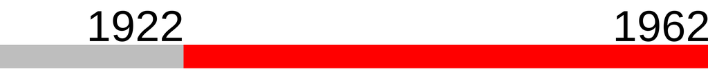

Africa

7

6

5

6

7

7

Colonized

[figure not shown]

Democratic Republic of the Congo

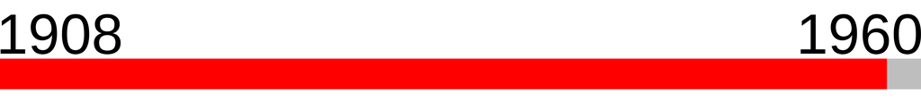

Africa

6

6

6

7

7

6

Colonized

[figure not shown]

Rwanda

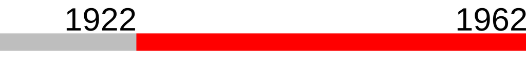

Africa

6

6

6

7

6

6

UK and its victims

Colonizer

[figure not shown]

United Kingdom of Great Britain and Northern Ireland

Europe

2

1

1

1

1

1

Colonized

[figure not shown]

Bahamas

Americas

2

1

1

1

1

1

Colonized

[figure not shown]

Barbados

Americas

1

1

1

1

1

1

Colonized

[figure not shown]

Canada

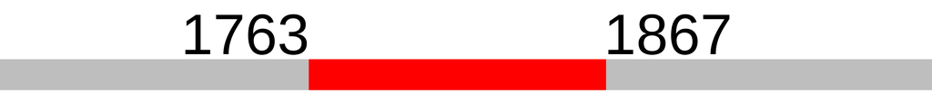

Americas

1

1

1

1

1

1

Colonized

[figure not shown]

United States of America

Americas

1

2

1

1

2

1

Colonized

[figure not shown]

Cyprus

Asia

1

1

1

1

1

1

Colonized

[figure not shown]

Ireland

Europe

1

1

1

1

1

1

Colonized

[figure not shown]

Malta

Europe

1

1

1

1

2

1

Colonized

[figure not shown]

Australia

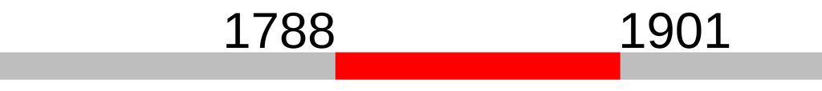

Oceania

1

1

1

1

1

1

Colonized

[figure not shown]

New Zealand

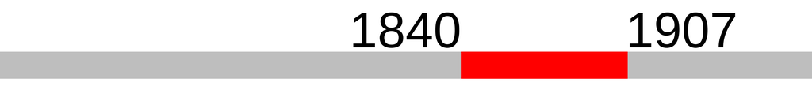

Oceania

1

1

1

1

1

1

Colonized

[figure not shown]

Ghana

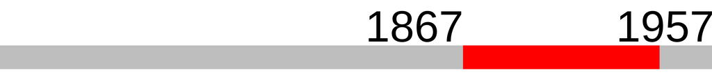

Africa

4

2

2

4

2

1

Colonized

[figure not shown]

Belize

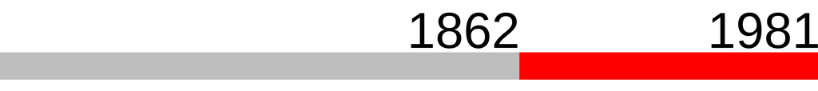

Americas

1

1

2

1

2

1

Colonized

[figure not shown]

Israel

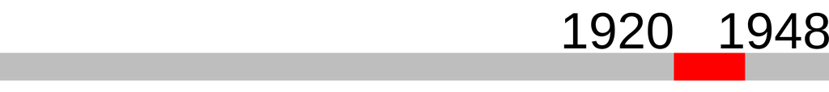

Asia

3

3

2

1

2

1

Colonized

[figure not shown]

Botswana

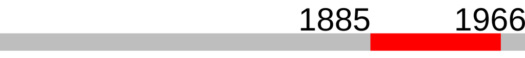

Africa

2

2

2

2

3

2

Colonized

[figure not shown]

South Africa

[figure not shown]

Africa

2

2

2

1

2

2

Colonized

[figure not shown]

Guyana

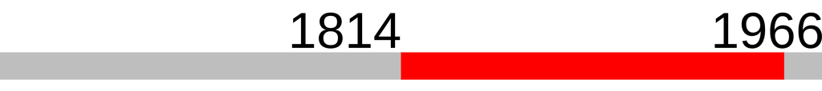

Americas